# Case Study Report

Futu Chen

2023-01-26

# 1 Overview

In this report, I first presented strength and limitations of the paper, then move on to a case-study with preliminary results.

### Report highlights

- Strengths and limitations were addressed.
- Potential additional statistical methods were proposed.
- In a simple model, no distributed lags were considered. I examined the association between 0-1 moving average PM exposure, and COVID-19 cases with generalized additive mixed effect models with a zero-inflated Poisson link function. This set of analyses was used to pick smooth functions for weather covariates.
- I then used a two-stage statistical approach. County-specific COVID-19 risks were estimated in stage 1 using a distributed lag model with a quasi-Poisson link function to account for overdispersion. Although different exposure and lag functions were explored, the exposure function was assumed to be linear, the same as lag functions, to keep things simple.
- In the second stage, I used the mixed-effects model to pool the association.
- Significant heterogeneity between counties was confirmed with Univariate Cochran Q-test for heterogeneity.
- Pooled results were not consistent with the reading, and even showed a protective effect. However, results were subjected to the model misspecification and potential errors in the code (my first time applying `dlnm` with `mixmeta`).

# 2 Article review

## 2.1 Strength

The strength of this paper lies in its methods that accommodate the complex environmental and outcome data. Specifically, it considered the delayed effect on the COVID-19 cases and temporal correlations between time series. Although the dose-response function is linear at each lag by a-priori, time-varying confounding was treated using spline to ensure minimal residual confounding. Since seasonal and temporal trends were controlled using time, weather, and mobility (in sensitivity analysis) variables, residual confounding by policy change, healthcare abilities, and other factors that fluctuate with time mentioned in the limitation should be limited. In addition, extended sensitivity analysis showed the robustness of the study under additional restrictions and different lags. Lastly, this study is highly reproducible and thus informative for future studies that investigate larger population-level effects or ask questions about effect modification, such as by age, education, and racial composition of the counties.

## 2.2 Limitations

This is a well-written and reviewed paper, and the limitation session has addressed most of my concerns while reading the context, such as confounding and additional model assumptions. I will discuss three limitations that are not extensively discussed in the paper. First, although distributed lag models partially handled temporal autocorrelation, this study did not consider spatial autocorrelation between counties, especially when COVID-19 is an infectious disease. Neighboring counties would likely share some correlation, and counties far apart geographically were more independent. In the 2-stage design, county-specific estimates might help to address this autocorrelation, but not enough. Future studies can ask questions such as on what spatial scale the associations matter (local or global) with geographically weighted regression to inform policy practices. Second, for COVID-19 deaths, the study did not adjust for the depletion of the pool, which would reduce the potential cases for long-term lags, especially in less populated counties. If a high PM day accelerated the death, then the association at a longer lag would seem protective compared to the days immediately following the high PM day. Third, under wildfire analysis, the assumption was that historical PM would be exchangeable with PM in 2020 had there been no wildfires. This might not be true if the concentration-response function was different comparing historical PM and 2020 PM under wildfire events.

# 3 Case Study

## 3.1 Opening: Background and confession

“*Free access to data doesn’t turn into knowledge without effort*”

–*Hans Rosling*

### 3.1.1 In an ideal world

While examining the data, I found a substantial zero cases or deaths days. In addition, evidence of seasonality and nonlinear associations between covariates and the outcomes were founded. Based on this evidence, in an ideal world, a distributed lag zero-inflated Poisson penalized regression (with correction for overdispersion) can be employed in stage 1 and then meta-regress with random intercepts or slopes in stage 2. Very much like what the reading did.

### 3.1.2 The reality

The reality is far away from ideal.

My workflow got stuck at stage 1 due to my limited experience working with similar projects. Suppose I use package `dlnm` (distributed lag models) and `gam()` (taking advantage of its penalized splines and zero-inflated Poisson family). In that case, I have no idea how to incorporate the results into stage 2 (with package `mixmeta`).

On the other hand, if I use distributed lag model with glm (with nature splines), I can only employ quasi-Poisson and give up zero-inflated. Additionally, penalized models are not possible.

Alternatively, another approach to the “ideal world analysis” is to use a `glmm` with random county intercept/slopes (at the end of the day, I used `bam()` function due to a family choice issue). This way, I can incorporate `dlnm` objects, specify zero-inflated family, use penalized regression, and account for county heterogeneity. However, can I incorporate effect modification into `glmm`? Maybe, since wildfire isn’t county-constant. But I feel this approach is not correct. So I kept it as a cross-check.

After getting stuck on these three options, I reached out for help. I asked if people have successfully used `dlnm` with `mgcv` and `mixmeta`. Unfortunately, I didn’t get any surprises.

When I decided to submit my work with `bam()`, my hero **Barrak Alahmad** replied. He used `dlnm` with `mixmeta`, but without `mgcv`. I received a sample code from Barrak. I did not disclose the context of my project or discuss additional analytic plans with Barrak (except complaining about my above-mentioned coding drama).

Thus, I confirmed that the 2-stage approach is doable if I quit the zero-inflated model and stick to nature splines. **With special thanks to Barrak**, I will present you the following analysis and results.

Additional reference:

- chrome-extension://efaidnbmnnnibpcajpcglclefindmkaj/https://cran.r-project.org/web/packages/dlnm/vignettes/dlnmTS.pdf
- https://github.com/gasparrini

## 3.2 Methods

## 3.3 Exposure Assessment

$PM_{2.5}$ was modeled as a moving average between the present and previous day (0-1) in the first set of (initial) analyses. A distributed lag model with 28 days of lag was fitted later on using quasi Poisson generaliazed linear models.

```r
lag <-function(x,n) {
  nn<-length(x)
  xn<-c(rep(NA,n),x[1:(nn-n)])
  return(xn)
}
dat$pm25_lag1 <- lag(dat$pm25,1)
dat$pm25_01avg <- (dat$pm25+dat$pm25_lag1)/2
```

### 3.3.1 Outcome Assessment

Only COVID-19 cases were used for the purpose of the case study. Log population size was used as an offset.

### 3.3.2 Covariates

Covariates included relative humidity (natural cubic spline with df=3), temperature (natural cubic spline df=2), day of the week, and time trend (natural cubic spline df=5). Due to high missingness, mobility was not included. Smooth functions were determined using aggregated data.

Selection was based on eyeball test…

```r
mdlist <- readRDS(paste0(model_dir,"cov_explore.rds")) # stored model to reduce knitting time

# smd2 <- gam(cases ~ pm25_01avg + s(date_num,bs = "cr",fx=TRUE,k=5) + s(tmmx, bs="cr",fx=FALSE) + s(rmax, bs="cr",fx=FALSE) + as.factor(dayofweek) , family=ziP(), offset=log(population), data = dat, na.action=na.omit)#zero-inflated
 smd2 <- mdlist[[2]]
summary(smd2)
```

```
##
## Family: Zero inflated Poisson(-0.681,0.307)
## Link function: identity
##
## Formula:
## cases ~ pm25_01avg + s(date_num, bs = "cr", fx = TRUE, k = 5) +
##     s(tmmx, bs = "cr", fx = FALSE) + s(rmax, bs = "cr", fx = FALSE) +
##     as.factor(dayofweek)
##
## Parametric coefficients:
##                                 Estimate Std. Error   z value Pr(>|z|)
## (Intercept)                   -9.1701673  0.0021881 -4190.831  < 2e-16 ***
## pm25_01avg                     0.0002123  0.0000498     4.264 2.01e-05 ***
## as.factor(dayofweek)Monday     0.0900333  0.0025819    34.871  < 2e-16 ***
## as.factor(dayofweek)Saturday   0.0319004  0.0026543    12.018  < 2e-16 ***
## as.factor(dayofweek)Sunday    -0.1588973  0.0027647   -57.475  < 2e-16 ***
## as.factor(dayofweek)Thursday  -0.0368978  0.0027456   -13.439  < 2e-16 ***
## as.factor(dayofweek)Tuesday   -0.0777434  0.0026757   -29.056  < 2e-16 ***
## as.factor(dayofweek)Wednesday -0.0646454  0.0026553   -24.346  < 2e-16 ***
## ---
## Signif. codes:  0 '***' 0.001 '**' 0.01 '*' 0.05 '.' 0.1 ' ' 1
##
## Approximate significance of smooth terms:
##               edf Ref.df  Chi.sq p-value
## s(date_num) 4.000  4.000 1156225  <2e-16 ***
## s(tmmx)     8.945  8.999   28765  <2e-16 ***
## s(rmax)     8.970  8.999   15088  <2e-16 ***
## ---
## Signif. codes:  0 '***' 0.001 '**' 0.01 '*' 0.05 '.' 0.1 ' ' 1
##
## Deviance explained =  100%
## -REML = 4.9201e+05  Scale est. = 1         n = 25316
```

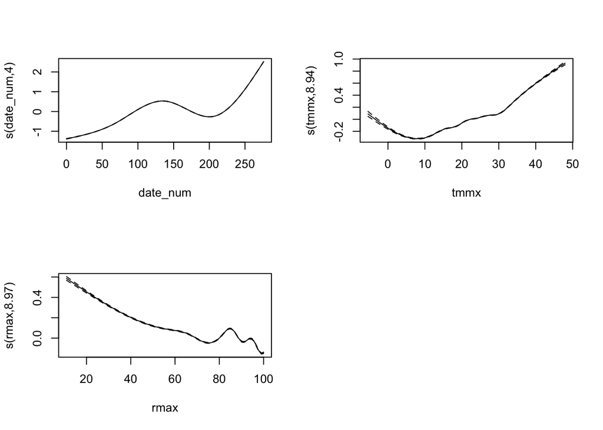

```r
plot(smd2,scale=0,pages=1) #looks like 2-3 df for temp(df=2)  and rh (df=3) is fine
```

```r
# smd3 <- gam(cases ~ pm25_01avg + s(date_num,bs = "cr",fx=TRUE,k=5) + s(tmmx, bs="cr",fx=FALSE, k=2) + s(rmax, bs="cr",fx=FALSE, k=3) + as.factor(dayofweek) , family=ziP(), offset=log(population), data = dat, na.action=na.omit)#zero-inflated
smd3 <- mdlist[[3]]
summary(smd3)
```

```
##
## Family: Zero inflated Poisson(-0.691,0.309)
## Link function: identity
##
## Formula:
## cases ~ pm25_01avg + s(date_num, bs = "cr", fx = TRUE, k = 5) +
##     s(tmmx, bs = "cr", fx = FALSE, k = 2) + s(rmax, bs = "cr",
##     fx = FALSE, k = 3) + as.factor(dayofweek)
##
## Parametric coefficients:
##                                 Estimate Std. Error   z value Pr(>|z|)
## (Intercept)                   -9.157e+00  2.161e-03 -4237.321  < 2e-16 ***
## pm25_01avg                     3.212e-04  4.899e-05     6.557 5.48e-11 ***
## as.factor(dayofweek)Monday     9.162e-02  2.564e-03    35.730  < 2e-16 ***
## as.factor(dayofweek)Saturday   3.462e-02  2.647e-03    13.079  < 2e-16 ***
## as.factor(dayofweek)Sunday    -1.566e-01  2.754e-03   -56.871  < 2e-16 ***
## as.factor(dayofweek)Thursday  -3.142e-02  2.722e-03   -11.544  < 2e-16 ***
## as.factor(dayofweek)Tuesday   -7.994e-02  2.648e-03   -30.185  < 2e-16 ***
## as.factor(dayofweek)Wednesday -6.750e-02  2.640e-03   -25.570  < 2e-16 ***
## ---
## Signif. codes:  0 '***' 0.001 '**' 0.01 '*' 0.05 '.' 0.1 ' ' 1
##
## Approximate significance of smooth terms:
##               edf Ref.df  Chi.sq p-value
## s(date_num) 4.000      4 1214240  <2e-16 ***
## s(tmmx)     2.000      2   22770  <2e-16 ***
## s(rmax)     1.998      2   11710  <2e-16 ***
## ---
## Signif. codes:  0 '***' 0.001 '**' 0.01 '*' 0.05 '.' 0.1 ' ' 1
##
## Deviance explained =  100%
## -REML = 4.9601e+05  Scale est. = 1         n = 25316
```

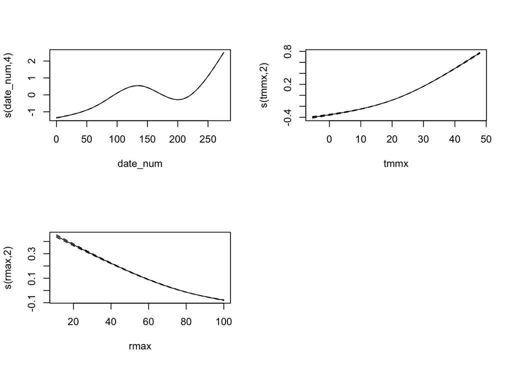

```r
plot(smd3,scale=0,pages=1)
```

### 3.3.3 Effect modification (ignored)

Initially, I thought about adding the wildfire*PM interaction term. However, questions came up about: how do I define interaction. Linear? Non-linear? What’s the relationship with distributed lags? Specific lags?

I think including wildfire complicates this preliminary study, so I did not include wildfire in the analysis.

## 3.4 Results

### 3.4.1 Optimal exposure and lag functions

A set of exposure functions ($f(x)$) and lag functions $w(l)$ were explored to pick the optimal combination. Selection was based on residual plots.

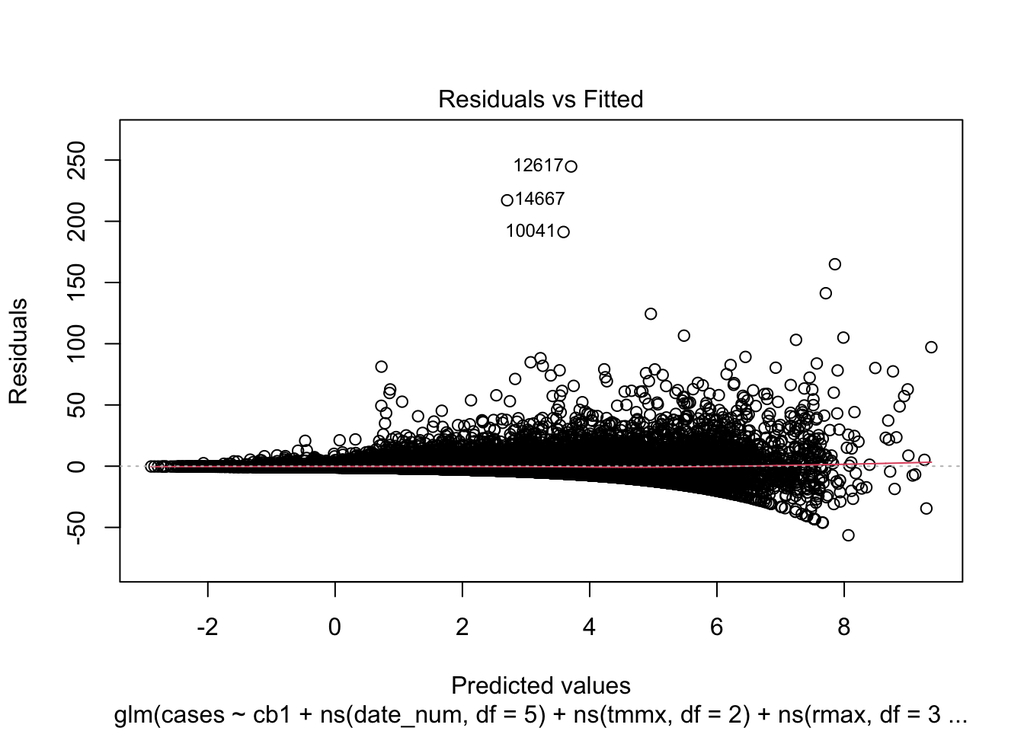

Residual plots from a set of exposure/lag functions

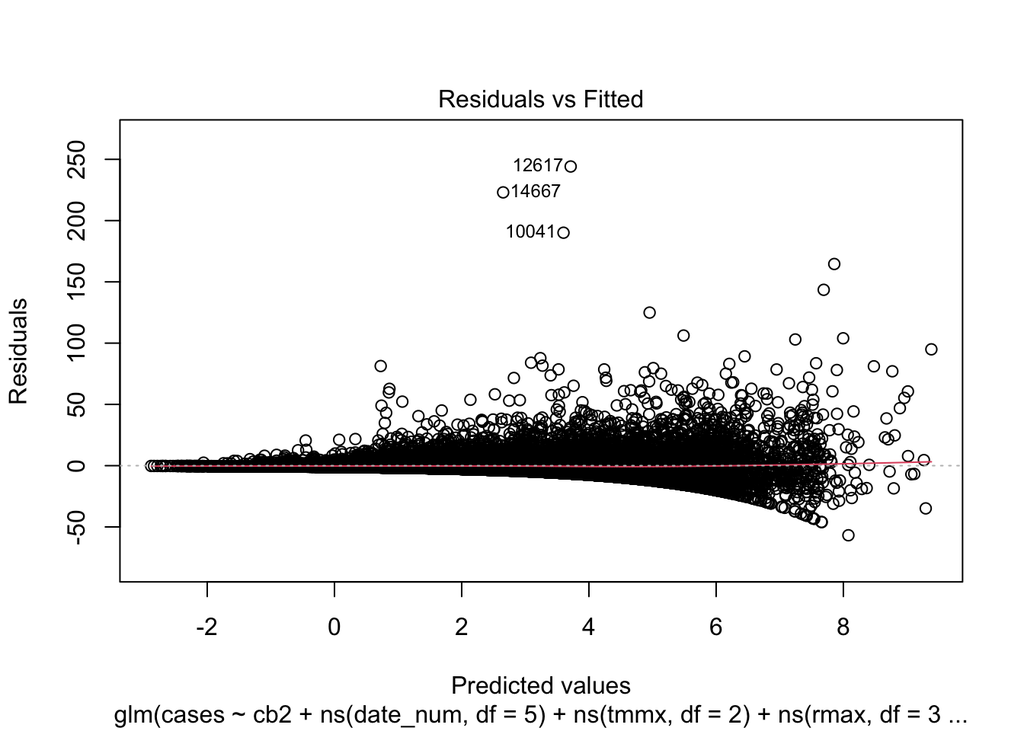

Residual plots from a set of exposure/lag functions

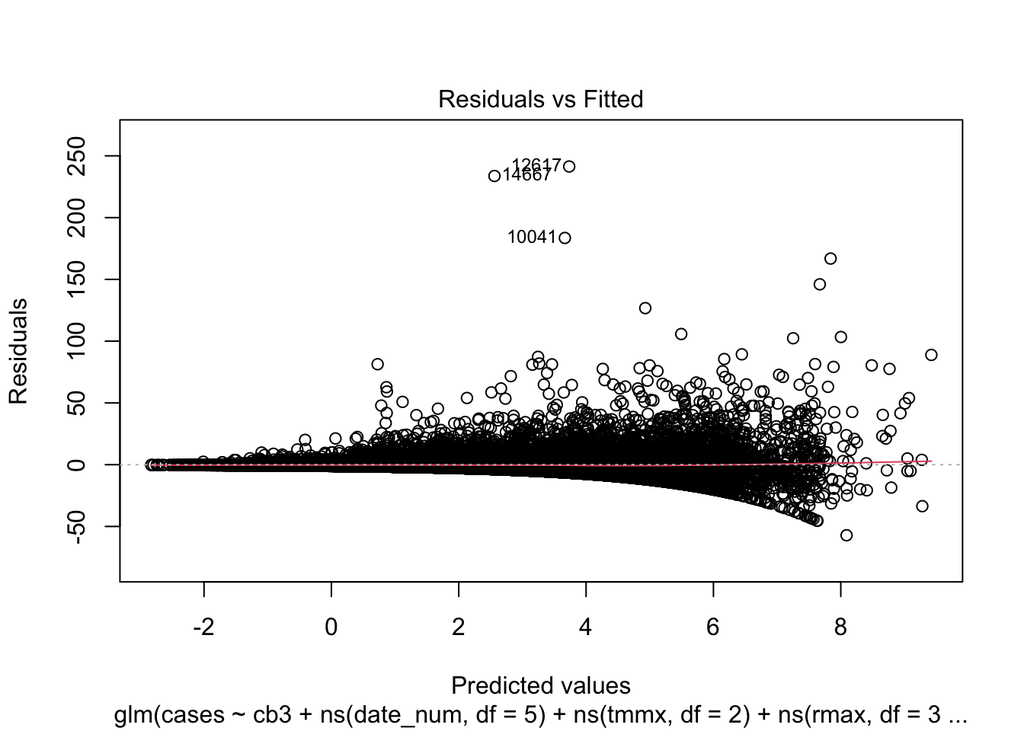

Residual plots from a set of exposure/lag functions

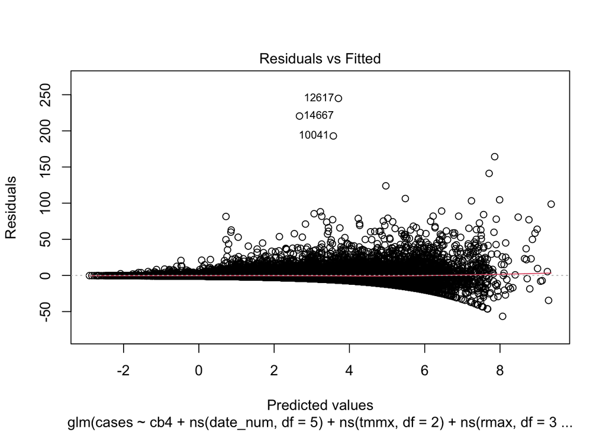

Residual plots from a set of exposure/lag functions

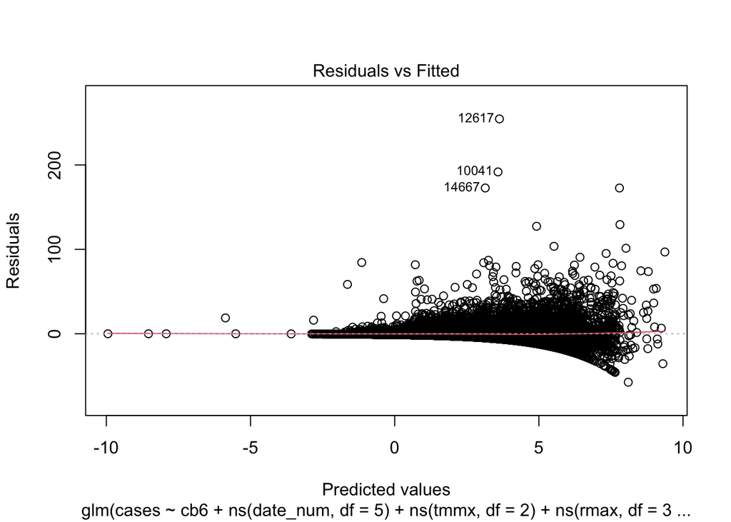

Residual plots from a set of exposure/lag functions

```r
mdlist <- readRDS(paste0(model_dir,"cb_explore.rds"))
# cb1 <- crossbasis(dat$pm25, lag=28, argvar=list("lin"), arglag=list("lin"))
# cb2 <- crossbasis(dat$pm25, lag=28, argvar=list("poly",degree=2), arglag=list("lin")) # exposure function a poly of degree 2
# cb3 <- crossbasis(dat$pm25, lag=28, argvar=list("poly",degree=4), arglag=list("lin")) # exposure function a poly of degree 4
# cb4 <- crossbasis(dat$pm25, lag=28, argvar=list("lin"), arglag=list(fun="strata"))  #lag function
# cb5 <- crossbasis(dat$pm25, lag=28, argvar=list("lin"), arglag=list(fun="ns",knots=logknots(28,4))) #change knots
# cb5 <- crossbasis(dat$pm25, lag=28, argvar=list("lin"), arglag=list(fun="ns",knots=logknots(28,8)))
# cb6 <- crossbasis(dat$pm25, lag=28, argvar=list("poly",degree=2), arglag=list(fun="ns",knots=logknots(28,4)))

for (i in 1:6) {
  plot(mdlist[[i]], which=1)
}
```

[output not shown]

### 3.4.2 First Stage

Here I used selected functions to estimate county-specific $\hat\beta_{PM}$.

```r
fips <- split(dat, dat$FIPS.f)

coefall <- matrix(NA,length(fips),2,dimnames=list(names(fips)))
vcovall <- vector("list",length(fips))
names(vcovall) <- names(fips)
mdall <- vector("list",length(fips))

for (i in 1:length(fips.list)) {
  data <- filter(dat, FIPS.f %in% fips.list[i])
  # cb for pm
  cb <-  crossbasis(data$pm25, lag=28, argvar=list("lin"), arglag=list(fun="lin"))
  md <- glm(cases ~ cb + ns(date_num, df=5) + ns(tmmx, df=2) + ns(rmax, df=3) + as.factor(dayofweek), data , family=quasipoisson, offset=log(population), na.action="na.exclude")
  predmean <- crosspred(cb,md,cen=mean(data$pm25,na.rm=T))
  mdall[[i]] <- predmean
   coefall[i,] <- coef(mdall[[i]])
   vcovall[[i]] <- vcov(mdall[[i]])
  # #reduce to one dim
  # md.reduce <- crossreduce(cb, md,cen=mean(data$pm25,na.rm=T))
  # mmt <- md.reduce$predvar[which.min(md.reduce$fit)[[1]]]
  # mdall[[i]] <- crossreduce(cb, md,cen=mmt)
  # coefall[i,] <- coef(mdall[[i]])
  # vcovall[[i]] <- vcov(mdall[[i]])
 }#FIPS

# one-dim
coefall.1dim <- matrix(NA,length(fips),1,dimnames=list(names(fips)))
vcovall.1dim <- vector("list",length(fips))
names(vcovall.1dim) <- names(fips)
mdall.1dim <- vector("list",length(fips))

for (i in 1:length(fips.list)) {
  data <- filter(dat, FIPS.f %in% fips.list[i])
  # cb for pm
  cb <-  crossbasis(data$pm25, lag=28, argvar=list("lin"), arglag=list(fun="lin"))
  md <- glm(cases ~ cb + ns(date_num, df=5) + ns(tmmx, df=2) + ns(rmax, df=3) + as.factor(dayofweek), data , family=quasipoisson, offset=log(population), na.action="na.exclude")
  #reduce to one dim
  md.reduce <- crossreduce(cb, md,cen=mean(data$pm25,na.rm=T))
  mmt <- md.reduce$predvar[which.min(md.reduce$fit)[[1]]]
  mdall.1dim[[i]] <- crossreduce(cb, md,cen=mmt)
  coefall.1dim[i,] <- coef(mdall.1dim[[i]])
  vcovall.1dim[[i]] <- vcov(mdall.1dim[[i]])
 }#FIPS
```

### 3.4.3 Second Stage

Let’s pool the estimates with vcov structures.

```r
# create dataset with 1 dim
dat.pool <- as.data.frame( as.character(as.factor(fips.list)))
dat.pool$coeff <- unlist(coefall.1dim)
dat.pool$vcov <- unlist(vcovall.1dim)
colnames(dat.pool) <-c("FIPS","coeff","vcov")
dat.pool$FIPS_num <- as.numeric(as.character(dat.pool$FIPS))
#    6    41    53
dat.pool$state <- ifelse(dat.pool$FIPS_num <10000, "CA", ifelse(dat.pool$FIPS_num <50000, "OR", "WA"))

# meta null
md.null <- mixmeta(coefall ~ 1, vcovall,control=list(showiter=T, igls.inititer=10),method="reml")
```

```
## IGLS iterations:
## iter 0: value -453.3374
## iter 1: value -822.3047
## iter 2: value -1096.154
## iter 3: value -1244.856
## iter 4: value -1279.413
## iter 5: value -1283.117
## iter 6: value -1283.931
## iter 7: value -1284.18
## iter 8: value -1284.258
## iter 9: value -1284.282
## Newton iterations:
```

```r
summary(md.null)
```

```
## Call:  mixmeta(formula = coefall ~ 1, S = vcovall, method = "reml",
##     control = list(showiter = T, igls.inititer = 10))
##
## Multivariate random-effects meta-analysis
## Dimension: 2
## Estimation method: REML
##
## Fixed-effects coefficients
##     Estimate  Std. Error        z  Pr(>|z|)  95%ci.lb  95%ci.ub
## y1   -0.0001      0.0001  -1.5628    0.1181   -0.0003    0.0000
## y2   -0.0000      0.0000  -0.9622    0.3359   -0.0000    0.0000
## ---
## Signif. codes:  0 '***' 0.001 '**' 0.01 '*' 0.05 '.' 0.1 ' ' 1
##
## Random-effects (co)variance components
##  Structure: General positive-definite
##     Std. Dev     Corr
## y1    0.0005       y1
## y2    0.0000  -0.7565
##
## Multivariate Cochran Q-test for heterogeneity:
## Q = 409.8073 (df = 182), p-value = 0.0000
## I-square statistic = 55.6%
##
## 92 units, 2 outcomes, 184 observations, 2 fixed and 3 random-effects parameters
##     logLik         AIC         BIC
##  1284.2910  -2558.5820  -2542.5620
```

```r
# add fixed effects
md1 <- mixmeta(coeff~0+FIPS, vcov, data=dat.pool)
summary(md1)
```

```
## Call:  mixmeta(formula = coeff ~ 0 + FIPS, S = vcov, data = dat.pool)
##
## Univariate random-effects meta-regression
## Dimension: 1
## Estimation method: REML
##
## Fixed-effects coefficients
##            Estimate  Std. Error        z  Pr(>|z|)   95%ci.lb  95%ci.ub
## FIPS41001   -0.0486      0.0382  -1.2734    0.2029    -0.1235    0.0262
## FIPS41003    0.0094      0.0318   0.2953    0.7678    -0.0530    0.0717
## FIPS41009    0.0145      0.0322   0.4507    0.6522    -0.0485    0.0775
## FIPS41013   -0.0134      0.0328  -0.4091    0.6825    -0.0778    0.0509
## FIPS41017    0.0013      0.0318   0.0416    0.9668    -0.0610    0.0636
## FIPS41019    0.0094      0.0319   0.2945    0.7684    -0.0531    0.0719
## FIPS41023    0.0604      0.1031   0.5857    0.5581    -0.1416    0.2624
## FIPS41025   -0.2115      0.0837  -2.5278    0.0115    -0.3755   -0.0475  *
## FIPS41029   -0.0096      0.0318  -0.3039    0.7612    -0.0719    0.0526
## FIPS41031    0.0012      0.0318   0.0390    0.9689    -0.0610    0.0635
## FIPS41033    0.0069      0.0319   0.2157    0.8293    -0.0556    0.0694
## FIPS41035    0.0357      0.0342   1.0442    0.2964    -0.0313    0.1027
## FIPS41037   -0.0051      0.0580  -0.0875    0.9303    -0.1188    0.1087
## FIPS41043    0.0015      0.0317   0.0487    0.9612    -0.0606    0.0637
## FIPS41047   -0.0035      0.0317  -0.1116    0.9112    -0.0656    0.0585
## FIPS41051   -0.0040      0.0317  -0.1270    0.8989    -0.0662    0.0582
## FIPS41059   -0.0035      0.0318  -0.1096    0.9128    -0.0658    0.0588
## FIPS41061   -0.0435     80.3391  -0.0005    0.9996  -157.5053  157.4183
## FIPS41063    0.0128      0.0368   0.3475    0.7282    -0.0593    0.0849
## FIPS41067   -0.0020      0.0317  -0.0615    0.9510    -0.0642    0.0603
## FIPS53001   -0.0164      0.0332  -0.4954    0.6203    -0.0815    0.0486
## FIPS53003    0.0041      0.0333   0.1223    0.9027    -0.0612    0.0694
## FIPS53005   -0.0028      0.0322  -0.0874    0.9303    -0.0659    0.0603
## FIPS53007   -0.0118      0.0323  -0.3667    0.7138    -0.0751    0.0514
## FIPS53009   -0.0267      0.0343  -0.7768    0.4373    -0.0939    0.0406
## FIPS53011    0.0080      0.0318   0.2501    0.8025    -0.0544    0.0703
## FIPS53013   -1.5099      0.6042  -2.4991    0.0124    -2.6941   -0.3258  *
## FIPS53015    0.0129      0.0324   0.3997    0.6894    -0.0505    0.0764
## FIPS53021   -0.0033      0.0324  -0.1017    0.9190    -0.0669    0.0603
## FIPS53025    0.0009      0.0323   0.0294    0.9765    -0.0623    0.0642
## FIPS53027    0.0021      0.0323   0.0656    0.9477    -0.0611    0.0654
## FIPS53029    0.0054      0.0407   0.1335    0.8938    -0.0744    0.0852
```

[output cut: 60 more lines]

```
## ---
## Signif. codes:  0 '***' 0.001 '**' 0.01 '*' 0.05 '.' 0.1 ' ' 1
##
## Random-effects (co)variance components
##  Structure: General positive-definite
##   Std. Dev
##     0.0316
##
## Univariate Cochran Q-test for residual heterogeneity:
## Q = 0.0000 (df = 0), p-value = 0.0000
## I-square statistic = 100.0%
##
## 92 units, 1 outcome, 92 observations, 92 fixed and 1 random-effects parameters
##   logLik       AIC       BIC
##  -0.0000  186.0000      -Inf
```

```r
# county nested in state
md2 <- mixmeta(coeff, vcov, data=dat.pool, random=~1|state/FIPS)
summary(md2)
```

```
## Call:  mixmeta(formula = coeff, S = vcov, data = dat.pool, random = ~1 |
##     state/FIPS)
##
## Univariate extended random-effects meta-analysis
## Dimension: 1
## Estimation method: REML
##
## Fixed-effects coefficients
##              Estimate  Std. Error        z  Pr(>|z|)  95%ci.lb  95%ci.ub
## (Intercept)   -0.0046      0.0030  -1.5315    0.1256   -0.0105    0.0013
## ---
## Signif. codes:  0 '***' 0.001 '**' 0.01 '*' 0.05 '.' 0.1 ' ' 1
##
## Random-effects (co)variance components
##  Formula: ~1 | state
##  Structure: General positive-definite
##   Std. Dev
##     0.0047
##
##  Formula: ~1 | FIPS
##  Structure: General positive-definite
##   Std. Dev
##     0.0086
##
## Univariate Cochran Q-test for heterogeneity:
## Q = 256.4649 (df = 91), p-value = 0.0000
## I-square statistic = 64.5%
##
## 92 units, 1 outcome, 92 observations, 1 fixed and 2 random-effects parameters
##    logLik        AIC        BIC
##  228.5503  -451.1005  -443.5680
```

```r
# heterogeneity
qtest(md.null)
```

```
## Multivariate Cochran Q-test for heterogeneity
##
## Overall test:
## Q = 409.807 (df = 182), p-value = 0.000
##
## Tests on single outcome parameters:
##           Q  df  p-value
## y1  196.240  91    0.000  ***
## y2  149.581  91    0.000  ***
## ---
## Signif. codes:  0 '***' 0.001 '**' 0.01 '*' 0.05 '.' 0.1 ' ' 1
```

```r
qtest(md1)
```

```
## Univariate Cochran Q-test for residual heterogeneity
## Q = 0.000 (df = 0), p-value = 0.000
```

```r
qtest(md2)
```

```
## Univariate Cochran Q-test for heterogeneity
## Q = 256.465 (df = 91), p-value = 0.000
```

```r
# test btw state
drop1(update(md1, .~state, method="ml"), test="Chisq")
```

```
## Single term deletions
##
## Model:
## coeff ~ state
##        Df     AIC    LRT Pr(>Chi)
## <none>    -461.42
## state   2 -455.80 9.6206 0.008145 **
## ---
## Signif. codes:  0 '***' 0.001 '**' 0.01 '*' 0.05 '.' 0.1 ' ' 1
```

```r
drop1(update(md2, .~state, method="ml"), test="Chisq")
```

```
## Single term deletions
##
## Model:
## coeff ~ state
##        Df     AIC    LRT Pr(>Chi)
## <none>    -459.42
## state   2 -456.57 6.8514  0.03253 *
## ---
## Signif. codes:  0 '***' 0.001 '**' 0.01 '*' 0.05 '.' 0.1 ' ' 1
```

```r
# est effects: RR
# pool from null model

library(Epi)
ci.exp(md.null) # protective! WHUT
```

```
##    exp(Est.)      2.5%    97.5%
## y1 0.9998847 0.9997400 1.000029
## y2 0.9999970 0.9999908 1.000003
```

```r
# results for each county
ci.exp(md1)
```

```
##           exp(Est.)         2.5%        97.5%
## FIPS41001 0.9525255 8.838207e-01 1.026571e+00
## FIPS41003 1.0094373 9.484200e-01 1.074380e+00
## FIPS41009 1.0145955 9.526315e-01 1.080590e+00
## FIPS41013 0.9866608 9.251740e-01 1.052234e+00
## FIPS41017 1.0013233 9.408338e-01 1.065702e+00
## FIPS41019 1.0094304 9.483063e-01 1.074494e+00
## FIPS41023 1.0622266 8.679307e-01 1.300018e+00
## FIPS41025 0.8093782 6.869651e-01 9.536046e-01
## FIPS41029 0.9903975 9.306434e-01 1.053988e+00
## FIPS41031 1.0012398 9.408107e-01 1.065550e+00
## FIPS41033 1.0068980 9.459158e-01 1.071812e+00
## FIPS41035 1.0363477 9.691734e-01 1.108178e+00
## FIPS41037 0.9949351 8.879649e-01 1.114792e+00
## FIPS41043 1.0015444 9.411939e-01 1.065765e+00
## FIPS41047 0.9964742 9.365317e-01 1.060253e+00
## FIPS41051 0.9959771 9.359236e-01 1.059884e+00
## FIPS41059 0.9965232 9.363271e-01 1.060589e+00
## FIPS41061 0.9574066 3.947338e-69 2.322140e+68
## FIPS41063 1.0128631 9.424172e-01 1.088575e+00
## FIPS41067 0.9980490 9.378369e-01 1.062127e+00
## FIPS53001 0.9836890 9.217300e-01 1.049813e+00
## FIPS53003 1.0040837 9.406024e-01 1.071849e+00
## FIPS53005 0.9971901 9.362151e-01 1.062136e+00
## FIPS53007 0.9882343 9.276613e-01 1.052763e+00
## FIPS53009 0.9736983 9.103709e-01 1.041431e+00
## FIPS53011 1.0079912 9.470301e-01 1.072877e+00
## FIPS53013 0.2209218 6.760093e-02 7.219787e-01
## FIPS53015 1.0130307 9.507121e-01 1.079434e+00
## FIPS53021 0.9967063 9.353258e-01 1.062115e+00
## FIPS53025 1.0009498 9.395854e-01 1.066322e+00
## FIPS53027 1.0021209 9.406861e-01 1.067568e+00
## FIPS53029 1.0054498 9.283413e-01 1.088963e+00
## FIPS53031 0.9592349 8.863488e-01 1.038115e+00
## FIPS53033 0.9858204 9.256314e-01 1.049923e+00
## FIPS53035 0.9930928 9.324471e-01 1.057683e+00
## FIPS53037 0.9958533 9.323318e-01 1.063703e+00
## FIPS53041 1.0073682 9.452612e-01 1.073556e+00
## FIPS53045 0.9992912 9.385054e-01 1.064014e+00
## FIPS53047 1.0039054 9.355618e-01 1.077241e+00
```

[output cut: 38 more lines]

```
## FIPS6073  1.0104390 9.403122e-01 1.085796e+00
## FIPS6075  0.9911498 9.298931e-01 1.056442e+00
## FIPS6077  1.0063433 9.429064e-01 1.074048e+00
## FIPS6079  0.9813840 9.081626e-01 1.060509e+00
## FIPS6081  0.9978667 9.356084e-01 1.064268e+00
## FIPS6083  1.0308446 9.362960e-01 1.134941e+00
## FIPS6085  0.9867200 9.264266e-01 1.050937e+00
## FIPS6087  1.0018101 9.387825e-01 1.069069e+00
## FIPS6095  0.9930925 9.310200e-01 1.059304e+00
## FIPS6097  0.9889690 9.262209e-01 1.055968e+00
## FIPS6099  0.9851124 9.230756e-01 1.051318e+00
## FIPS6101  0.9470431 8.844017e-01 1.014121e+00
## FIPS6107  0.9982132 9.366506e-01 1.063822e+00
## FIPS6111  0.9743315 8.706364e-01 1.090377e+00
## FIPS6113  0.9848005 9.241863e-01 1.049390e+00
```

```r
range(exp(predict(md1))) #range of effects
```

```
## [1] 0.2209218 1.0692098
```